# Continuous predictors: assumptions and interpretation

Fisher’s Z-transformed correlation coefficient ($Z_r$)

Published

September 25, 2026

As you have seen so far in this guide, effect sizes are not trivial things. Together, point estimates and sampling variances are small statistical models with their own numerical assumptions, properties, and quirks. Understanding these assumptions is essential if you want to conduct a proper and robust meta-analysis, and if you want to correctly interpret these effect sizes and the outputs of meta-analytic models.

In this section, we discuss effect sizes for describing the relationship strength between two continuous variables. These are known as measures of association. While the Pearson product-moment correlation coefficient ($r$) is the most intuitive and widely reported metric in primary studies, its mathematical properties make it problematic for direct meta-analytic pooling. Instead, we will dive into the elegant statistical world of **Fisher’s Z-transformed correlation coefficient** ($Z_r$), our variance-stabilizing alternative.

### Why can’t we just pool raw correlations?

When primary studies report their results, they often present Pearson’s correlation coefficient ($r$). It is an appealing effect size: it carries no units, so a correlation between body mass and clutch size can be compared directly against one between soil nitrogen and plant diversity (if that makes sense to be compared, which is another question). It runs from $-1$ (a perfect negative linear association) through $0$ (no *linear* association) to $+1$ (a perfect positive linear association).

In practice, many studies never report $r$ at all. Instead, they show a scatterplot, often with a fitted line from a linear model, and report a slope, a $t$ or $F$ statistic, or an $R^2$. In those cases you will have to obtain $r$ yourself, either by extracting the points from the figure (see Chapter 3.4) or by converting the reported test statistics (see Chapter 4).

**Tip📝 DRAFT: What $r$ actually measures**

It is easy to forget, if your last stats class was a while ago, that $r$ packs two things into a single number: the *direction* of the relationship and how *tightly* the points cluster around a straight line. It is not the slope. The two are linked by

$$r = b \, \frac{s_x}{s_y}
\tag{1}$$

where $b$ is the slope of the regression of $y$ on $x$, and $s_x$ and $s_y$ are the standard deviations of the two variables. The same slope can therefore come with a strong or a weak correlation, depending on how much scatter surrounds the line, and a very shallow slope can give $r$ close to $1$ if the points sit right on it (Fig. 1). Squaring $r$ gives $r^2$, the proportion of the variance in $y$ explained by a straight line on $x$ (the same $R^2$ as in a simple linear regression).

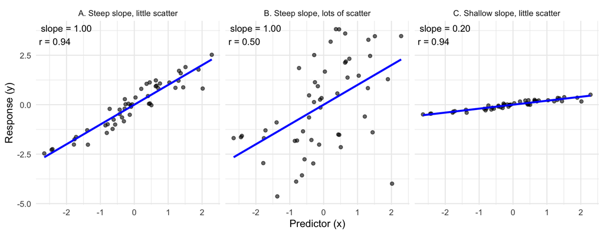

Figure 1— Three simulated datasets with the same 50 values of $x$. Panels A and B share the same slope but differ in scatter, so their correlations differ. Panels A and C have very different slopes but the same scatter relative to the slope, so their correlations are identical.

```r
set.seed(42)
n <- 50
x <- rnorm(n)
e <- as.numeric(scale(resid(lm(rnorm(n) ~ x))))  # noise uncorrelated with x, so the fitted slope equals b exactly
scenarios <- data.frame(
  panel = c("A. Steep slope, little scatter", "B. Steep slope, lots of scatter", "C. Shallow slope, little scatter"),
  b     = c(1, 1, 0.2),
  sigma = c(0.4, 2, 0.08)
)
sim <- do.call(rbind, lapply(seq_len(nrow(scenarios)), function(i) {
  data.frame(panel = scenarios$panel[i], x = x,
             y = scenarios$b[i] * x + scenarios$sigma[i] * e)
}))
labs_df <- do.call(rbind, lapply(split(sim, sim$panel), function(d) {
  data.frame(panel = d$panel[1],
             label = sprintf("slope = %.2f\nr = %.2f", coef(lm(y ~ x, data = d))[2], cor(d$x, d$y)))
}))
p <- ggplot(sim, aes(x = x, y = y)) +
  geom_point(alpha = 0.6) +
  geom_smooth(method = "lm", se = FALSE, color = "blue", linewidth = 1) +
  geom_text(data = labs_df, aes(x = -Inf, y = Inf, label = label),
            hjust = -0.1, vjust = 1.2, size = 3.5) +
  facet_wrap(~ panel) +
  theme_minimal() +
  labs(x = "Predictor (x)", y = "Response (y)")
p
```

For a meta-analysis, this means that two studies of identical biology (same slope) can report different correlations simply because one measured noisier data or sampled a narrower range of $x$ (see range restriction and measurement error below).

Convenient as it is, the raw correlation coefficient has three mathematical properties that sit awkwardly with the assumptions of standard meta-analytic models. All three trace back to a single issue: $r$ is bounded by $-1$ and $+1$, and statistical estimates behave badly near hard limits.

1. **The estimate gets squeezed against the ceiling.** When the true correlation in the population is near zero, repeated studies scatter symmetrically around it. When the true correlation is strong, say $+0.8$, there is simply less room to overshoot than to undershoot, because no estimate can exceed $+1$. The spread of plausible estimates becomes lopsided, with a long tail on the low side. The practical cost is that confidence intervals calculated the usual way assume a symmetric spread, so they end up miscalibrated and can even extend beyond $1$, which does not make sense. Separately, and through a different route, $r$ is a slightly *shrunken* estimate of the true correlation. It is pulled toward zero, whatever its sign. That shrinkage is small (for a true correlation of $0.5$ measured on $20$ individuals, roughly $0.01$), but it is the reason unbiased alternatives to $r$ exist (Olkin and Pratt 1958).
2. **Precision is tangled up with the result.** Meta-analysis weights each study by its precision, and this only works if precision is governed by something independent of the answer, such as sample size. For correlations it is not. The sampling variance of $r$ is

$$v_i = \frac{(1 - r_i^2)^2}{n_i - 1}
\tag{2}$$

which contains the correlation itself. The larger the correlation a study happens to report, the smaller its variance and the heavier its weight. A study that overestimated the correlation by chance is therefore rewarded with extra influence, and the pooled estimate is dragged away from zero. Notice that this pushes in the *opposite* direction to the shrinkage in point 1, above. The same entanglement distorts funnel plots and inflates the false-positive rate of Egger’s test for funnel asymmetry. The scatter narrows toward large correlations for reasons that have nothing to do with genuine precision.

3. **Small samples make matters worse.** Meta-analytic models assume each study’s estimate is drawn from a bell-shaped distribution around the true value. For correlations, that approximation holds up well with large samples and modest effects, and it breaks down when the sample is small *and* the correlation is strong—the combination most familiar to anyone working with a dozen populations or a handful of species.

To solve these issues, Fisher proposed a variance-stabilizing, normalizing transformation (Fisher 1921, Borenstein et al. 2021).

### The statistical mechanics of $Z_r$

#### 1. Fisher’s $Z$ transformation (the point estimate)

Fisher’s transformation stretches the bounded $[-1, +1]$ interval across the entire number line, pushing the ceilings out to infinity so that estimates are no longer squeezed against them. Formally, it is the inverse hyperbolic tangent ($\text{atanh}$):

$$y_i = Z_{r_i} = \text{atanh}(r_i) = \frac{1}{2} \ln\left(\frac{1 + r_i}{1 - r_i}\right)
\tag{3}$$

Both equal signs are exact: $\frac{1}{2} \ln\left(\frac{1 + r}{1 - r}\right)$ is simply the definition of $\text{atanh}(r)$. The approximations come in later, when we describe how $Z_r$ is distributed across studies.

Correlations near zero barely move. Correlations near the boundaries are stretched dramatically. The result is a distribution that is close to symmetric and close to normal for samples of roughly $10$ or more.

#### 2. The sampling variance

The real beauty of Fisher’s transformation lies in its sampling variance. After transformation, the sampling variance depends on sample size and nothing else:

$$v_i = \text{Var}(Z_{r_i}) = \frac{1}{n_i - 3} \tag{4}$$

The effect size has vanished from the variance entirely. Studies are now weighted purely by how much data they collected, which is exactly the assumption meta-analytic models were built on. Symmetry and approximate normality come along for free.

**NoteThe variance formula assumes bivariate normality**

Fisher’s variance is derived assuming the two variables follow a bivariate normal distribution. This means both variables are normal but covary. See [here](https://www.statisticshowto.com/bivariate-distribution/) to explore this distribution.

When the underlying data are strongly non-normal (heavy tailed) abundance counts, or ratios with a few extreme values, the true sampling variance can be noticeably larger than $1/(n_i - 3)$, and standard errors will be too optimistic (Kowalski 1972, Hawkins 1989). This is a further reason to prefer robust variance estimation (see below) when your evidence base is built on skewed ecological data.

What about a discrete variable, such as a binary treatment, a sex, or a presence/absence response? Pearson’s formula will still return a number (the *point-biserial correlation*), but a binary variable cannot be normal, so the bivariate normality assumption fails by construction. The variance $1/(n_i - 3)$ becomes a rough approximation, and the correlation itself is capped by how unevenly the two groups are split (see the point-biserial box under Not all correlations are comparable). For these designs, an SMD or $\ln\text{OR}$ is usually the better effect size. Discrete variables with many ordered levels (for example, counts spanning a wide range) are less of a problem, but the same caution applies.

#### 3. Back-transformation to $r$

We conduct all statistical modeling, random-effects estimation, and moderator tests in the $Z_r$ metric, but $Z_r$ values are difficult to interpret conceptually. An effect size of $Z_r = 1.1$ means very little to our brain until we convert it back to $r = 0.8$. We therefore back-transform final pooled estimates from our meta-analytic models, and the confidence intervals, to the intuitive correlation scale using the hyperbolic tangent ($\tanh$):

$$r = \tanh(Z_r) = \frac{e^{2 Z_r} - 1}{e^{2 Z_r} + 1} \tag{5}$$

In `R`, this looks like:

```r
tanh(1.1)
```

```
[1] 0.800499
```

**WarningBack-transformation is not a neutral operation**

Because the conversion from $Z_r$ to $r$ is curved rather than straight, back-transforming a pooled estimate does not return the average of the underlying correlations. It returns something closer to their median, and the gap between the two widens as between-study heterogeneity grows. In ecology and evolution, where heterogeneity is usually substantial, a back-transformed mean will typically exaggerate the magnitude of the true average correlation.

Three practical consequences:

- **Interval bounds back-transform safely.** Because the transformation preserves rank order, converting the two ends of a confidence or prediction interval gives valid bounds on the $r$ scale. So, convert the endpoints, never the standard error.
- **Heterogeneity does not back-transform at all.** Report $\tau^2$, $I^2$, and prediction intervals on the $Z_r$ scale, or convert the prediction interval endpoints only. There is no meaningful “$\tau^2$ in correlation units.”
- **Word your conclusion carefully.** “The pooled effect corresponds to a correlation of 0.42” is defensible; “the average correlation across studies was 0.42” is not, once heterogeneity is appreciable.

Some authors (notably the Hunter–Schmidt tradition; Hunter and Schmidt (2014); Field (2001)) respond to this by pooling raw correlations with sample-size weights instead. We use Fisher’s $Z_r$ throughout this guide because it solves three problems at once, but the choice is genuinely contested and worth considering.

### Code and formula pairing: implementation in R

Let’s look at how to implement these calculations in R using `metafor::escalc` and basic math.

Note that in many cases, the $Z_r$ effect sizes that you calculate in a meta-analysis will involve multiple steps. Few studies report $r$ directly. Instead many of those studies will present scatterplot visualizations, which they analyze with linear models. To calculate $r$ (the precursor to $Z_r$), you’ll have to extract the points from the scatterplot (or find their raw data) and calculate $r$ across the points.

As such, your raw dataset will be long, with a row per measurement point and an ID to specify the summarization group to calculate $r$. The sample size ($n$) will be the number of rows.

Once $r$ and $n$ are calculated the operation is simple. We’ll here show both calculating manually and with `escalc`.

```r
# Simple demonstration of Zr transformation and back-transformation in R

# Let's say we have extracted a correlation of r = 0.6 from a study of n = 50
r_val <- 0.6
n_val <- 50

# 1. Manual Fisher's Z transformation
z_manual <- 0.5 * log((1 + r_val) / (1 - r_val))
var_manual <- 1 / (n_val - 3)

# 2. Using escalc from metafor
dat_example <- data.frame(ri = r_val, ni = n_val)
dat_zr <- escalc(measure = "ZCOR", ri = ri, ni = ni, data = dat_example)

print(paste("Manual Z:", round(z_manual, 4)))
```

```
[1] "Manual Z: 0.6931"
```

```r
print(paste("escalc Z (yi):", round(dat_zr$yi[1], 4)))
```

```
[1] "escalc Z (yi): 0.6931"
```

```r
print(paste("escalc Z (vi):", round(dat_zr$vi[1], 4)))
```

```
[1] "escalc Z (vi): 0.0213"
```

```r
# 3. Back-transformation using tanh
r_back <- tanh(z_manual)
print(paste("Back-transformed r:", round(r_back, 4)))
```

```
[1] "Back-transformed r: 0.6"
```

**NoteFisher’s $Z$ in `metafor`**

The `metafor` package (Viechtbauer 2010) implements Fisher’s $Z$ transformation via the `measure` code `"ZCOR"`. This is the measure you want for the workflow in this chapter.

You may also encounter `"UCOR"`, which applies the Olkin-Pratt correction (Olkin and Pratt 1958) for the small-sample shrinkage described above. Be aware that `"UCOR"` returns a corrected *raw* correlation, not a transformed one. So it fixes the shrinkage while leaving the variance-effect entanglement fully intact. It is not an upgraded version of `"ZCOR"`, and the two should not be mixed within a single analysis. In general, we know of few cases where `"UCOR"` should be used instead of `"ZCOR"`.

Let’s plot how $r$ maps to $Z_r$. Notice how the relationship is nearly a straight line around zero but curves sharply as it approaches the boundaries of $-1$ and $+1$:

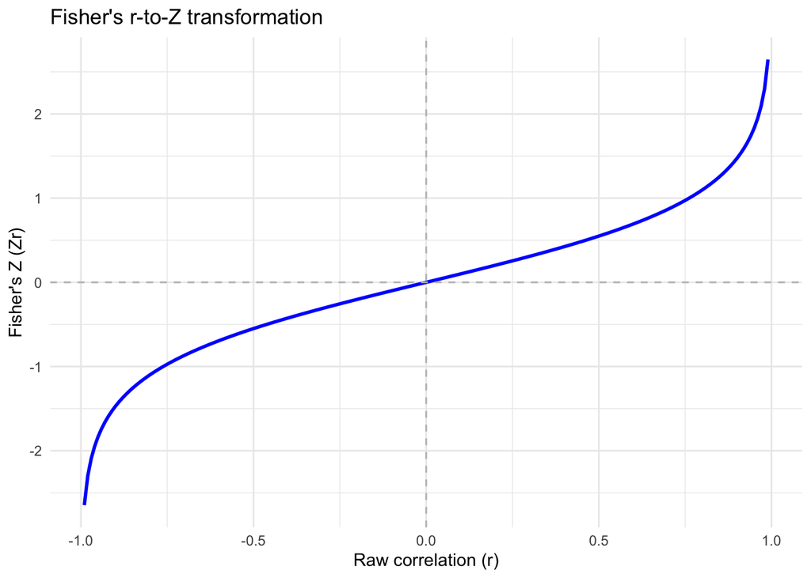

```r
r_seq <- seq(-0.99, 0.99, by = 0.01)
zr_seq <- atanh(r_seq)

plot_data <- data.frame(r = r_seq, zr = zr_seq)

ggplot(plot_data
  , aes(x = r
      ,y = zr)
  ) +
  geom_line(color = "blue", linewidth = 1) +
  theme_minimal() +
  labs(title = "Fisher's r-to-Z transformation"
    , x = "Raw correlation (r)"
    , y = "Fisher's Z (Zr)") +
    geom_vline(xintercept = 0, linetype = "dashed", color = "gray") +
    geom_hline(yintercept = 0, linetype = "dashed", color = "gray")
```

**Tip📝 DRAFT: What happens when $r = \pm 1$?**

Follow the curve above to its ends: as $r$ approaches $\pm 1$, $Z_r$ heads off to $\pm\infty$. At exactly $r = \pm 1$, Fisher’s transformation is undefined, since $\text{atanh}(1) = \infty$. The variance, however, looks perfectly well behaved, because $1/(n_i - 3)$ ignores $r$ entirely. Nothing in the variance formula warns you that something has gone wrong.

`escalc` deals with this by recoding the infinite values to `NA` (with a warning), and `rma` then drops those rows before fitting (with another warning). The consequence is easy to miss: the studies reporting the *strongest* associations quietly disappear from your analysis, pulling the pooled estimate toward zero.

```r
# Three studies; study A reports a perfect correlation
dat_perfect <- data.frame(study = c("A", "B", "C")
                          , ri = c(1, 0.45, 0.30)
                          , ni = c(8, 40, 60))

dat_perfect <- escalc(measure = "ZCOR", ri = ri, ni = ni, data = dat_perfect)
```

```
Warning: Some 'yi' and/or 'vi' values equal to +-Inf. Recoded to NAs.
```

```r
dat_perfect # Study A has NA for both yi and vi
```

```
  study   ri ni     yi     vi
1     A 1.00  8     NA     NA
2     B 0.45 40 0.4847 0.0270
3     C 0.30 60 0.3095 0.0175
```

```r
# Study A is dropped: the model is fitted to k = 2 studies
rma(yi, vi, data = dat_perfect)
```

```
Random-Effects Model (k = 2; tau^2 estimator: REML)

tau^2 (estimated amount of total heterogeneity): 0 (SE = 0.0315)
tau (square root of estimated tau^2 value):      0
I^2 (total heterogeneity / total variability):   0.00%
H^2 (total variability / sampling variability):  1.00

Test for Heterogeneity:
Q(df = 1) = 0.6885, p-val = 0.4067

Model Results:

estimate      se    zval    pval   ci.lb   ci.ub
  0.3785  0.1031  3.6694  0.0002  0.1763  0.5806  ***

---
Signif. codes:  0 '***' 0.001 '**' 0.01 '*' 0.05 '.' 0.1 ' ' 1
```

A reported $r = \pm 1$ almost always points to one of the following:

- **A tiny sample.** Any two points lie on a straight line, so $r = \pm 1$ is guaranteed at $n = 2$ and common at $n = 3$ or $4$. At $n \le 3$ the variance is undefined anyway, and `escalc` returns `NA` for $v_i$.
- **Rounding.** A table reporting $r = 1.00$ may hide an $r = 0.996$.
- **Aggregated data.** Correlations among a handful of group means are inflated toward $\pm 1$ (see ecological correlations below).
- **Variables that are not independent.** One variable is computed from the other (*e.g.,* body mass vs. a mass-based condition index), or the same measurement was entered twice.
- **Extraction or reporting errors.**

What to do:

1. **Go back to the source** and work out which of these applies. Fix errors, and exclude correlations between variables that were not measured independently.
2. **If rounding is the likely cause**, replace the value with the largest correlation consistent with the reported precision (*e.g.,* $0.995$ for a reported $1.00$), and flag it.
3. **Never pick an arbitrary ceiling without checking its influence.** Because $Z_r$ explodes near the boundary, the choice matters a great deal:

```r
ceilings <- c(0.99, 0.995, 0.999, 0.9999)

# Fisher's Z for each candidate ceiling
round(atanh(ceilings), 2)
```

```
[1] 2.65 2.99 3.80 4.95
```

```r
# Pooled estimate (back-transformed to r) when study A's r = 1 is replaced by each ceiling
sapply(ceilings, function(r_max) {
  dat_ceiling <- escalc(measure = "ZCOR"
                        , ri = pmin(ri, r_max)
                        , ni = ni
                        , data = dat_perfect)
  round(tanh(unname(coef(rma(yi, vi, data = dat_ceiling)))), 3)
})
```

```
[1] 0.798 0.838 0.904 0.955
```

Without study A, the pooled correlation is $r = 0.36$. Put study A back in, and the pooled correlation lands anywhere between $0.80$ and $0.96$, depending only on which ceiling you picked. A single tiny study with $n = 8$ ends up dominating the synthesis. Its inflated $Z_r$ makes the between-study variance balloon, and that flattens the weights of the larger studies.

Run your models with and without these studies, and under more than one ceiling. Report how much the pooled estimate depends on them.

### Not all correlations are comparable

Before converting anything, check that the correlations you have extracted are estimating the same quantity. Several common mismatches will quietly corrupt an otherwise careful meta-analysis.

**Partial correlations are not zero-order correlations.** A study reporting the association between temperature and growth rate *after controlling for* body size is reporting a different parameter from a study reporting the raw association. Pooling the two together answers no clear question. If you must include partial correlations, flag them, model them as a moderator, and adjust the sample size to account for the covariates that were controlled for (the variance is closer to $1/(n_i - k_i - 3)$, where $k_i$ is the number of control variables; Fisher (1924); Aloe and Thompson (2013)).

**Range restriction shrinks correlations** (Thorndike 1949, Sackett and Yang 2000). A study sampling across a narrow elevational band will report a weaker correlation than one spanning the full gradient, even if the underlying biology is identical. Where you can, record range or standard deviation of the predictor and use it as a moderator.

**Measurement error shrinks correlations too** (Spearman 1904, Hunter and Schmidt 2014). Noise proxies attenuate associations toward zero. If reliability estimates are available for some studies and not others, this becomes a source of heterogeneity you cannot see.

**Tip📝 DRAFT: Ecological (aggregate) correlations vs. individual correlations**

**Ecological correlations are not individual correlations.** When primary studies report correlations among group means (such as site averages) rather than individual measurements, they are estimating an *ecological correlation* (Robinson 1950). Because group averaging washes away individual-level residual variance, aggregate correlations are almost always substantially stronger (larger $|r|$) than individual-level correlations (aggregation bias / Robinson’s paradox). Mixing ecological correlations with individual correlations in the same meta-analysis introduces severe methodological heterogeneity. To resolve this, researchers often reconstruct individual-level data from group means and standard deviations (see Chapter 3.4, Section 3.4.3 for worked extraction and simulation protocols).

**Tip📝 DRAFT: Continuous predictors with binary outcomes (Point-biserial & Biserial)**

**Point-biserial and Biserial correlations.** When a continuous predictor is paired with a truly discrete binary outcome (*e.g.,* predator density vs. nest fledged/failed), calculating Pearson’s formula yields the *point-biserial correlation* ($r_{pb}$). A key mathematical constraint of $r_{pb}$ is that its maximum possible value is restricted by the base rate of the binary groups: unless the groups are split 50/50 ($p = q = 0.5$), $|r_{pb}|$ cannot mathematically reach 1.0 (Jacobs and Viechtbauer 2017). In contrast, the *biserial correlation* ($r_b$) assumes the binary outcome reflects an underlying continuous trait with a threshold. Fortunately, point-biserial correlations can be converted to Standardized Mean Differences ($d$) or log Odds Ratios ($\ln\text{OR}$) to unify continuous and discrete studies within the same synthesis (see Chapter 3.4, Section 3.4.5 and Chapter 4).

### Handling ranked correlations: Spearman’s $\rho$ and Kendall’s $\tau$

When voyaging through the literature, you will inevitably encounter studies that present raw data, scatterplots, or matrices, that need to be analyzed as $Z_r$ but are based on ranks rather than raw values. Or you will encounter studies that do not report Pearson’s $r$. Instead, because their data were non-normal or ranked, they reported **Spearman’s rank correlation** ($\rho$ or $r_s$) or **Kendall’s tau** ($\tau$).

- **Spearman’s $\rho$** is Pearson’s $r$ computed on the ranks of each variable rather than on their raw values. It measures how well the relationship is described by *any* monotonic curve, not just a straight line.
- **Kendall’s $\tau$** looks at every pair of observations and asks whether they are ordered the same way on both variables (a concordant pair) or in opposite ways (a discordant pair): $\tau = (C - D) / \binom{n}{2}$, where $C$ and $D$ are the numbers of concordant and discordant pairs. It is less sensitive to outliers and ties than $\rho$, and usually smaller in magnitude for the same data.

In `R`, both are available through `cor(x, y, method = "spearman")` and `cor(x, y, method = "kendall")`.

Because these metrics are based on ranks rather than raw values, their numeric scales are slightly compressed compared to Pearson’s $r$. To include these studies in your meta-analysis, you can apply the following transformations to approximate their Pearson equivalents:

#### Spearman’s $\rho$ to Pearson’s $r$:

$$r \approx 2 \sin\left(\frac{\pi}{6} \rho\right) \tag{6}$$

#### Kendall’s $\tau$ to Pearson’s $r$:

$$r \approx \sin\left(\frac{\pi}{2} \tau\right) \tag{7}$$

Both formulas assume the underlying data are bivariate normal (Kendall 1948, Rupinski and Dunlap 1996), which is very often the assumption the original authors doubted when they chose a rank method in the first place. Treat the conversions as approximations.

A useful refinement: once converted and Fisher-transformed, an effect size originating from Spearman’s $\rho$ is slightly noisier than one originating from Pearson’s $r$. Because ranks discard some metric information, converted rank correlations have slightly lower statistical efficiency than Pearson correlations, inflating the sampling variance of $Z_r$ by about 6% under bivariate normality (Fieller et al. 1957, Myers and Sirois 2004):

$$v_i \approx \frac{1.06}{n_i - 3} \tag{8}$$

As such, these converted effect sizes will have less influence on your meta-analytic models, which, at least is a conservative type of error.

**Tip📝 DRAFT: Converting rank correlations in R**

Here is the full workflow for a small dataset mixing Pearson, Spearman, and Kendall correlations: convert to Pearson equivalents, flag the conversions, compute $Z_r$, and inflate the variance of the Spearman-derived effect sizes.

```r
# Conversions to Pearson-equivalent r (@eq-spearman and @eq-kendall)
spearman_to_r <- function(rho) 2 * sin(pi / 6 * rho)
kendall_to_r  <- function(tau) sin(pi / 2 * tau)

dat_ranked <- data.frame(study = c("A", "B", "C", "D", "E", "F")
                         , type = c("pearson", "pearson", "pearson"
                                    , "spearman", "spearman", "kendall")
                         , reported = c(0.42, 0.31, 0.55, 0.38, 0.60, 0.25)
                         , ni = c(35, 60, 22, 50, 42, 28))

dat_ranked$ri <- ifelse(dat_ranked$type == "spearman", spearman_to_r(dat_ranked$reported),
                 ifelse(dat_ranked$type == "kendall", kendall_to_r(dat_ranked$reported),
                        dat_ranked$reported))

# Flag converted effect sizes for sensitivity analyses
dat_ranked$is_converted <- dat_ranked$type != "pearson"

dat_ranked <- escalc(measure = "ZCOR", ri = ri, ni = ni, data = dat_ranked)

# Inflate the sampling variance of Spearman-derived effect sizes (@eq-rank-inflation)
dat_ranked$vi <- ifelse(dat_ranked$type == "spearman", dat_ranked$vi * 1.06, dat_ranked$vi)

dat_ranked
```

```
  study     type reported ni        ri is_converted     yi     vi
1     A  pearson     0.42 35 0.4200000        FALSE 0.4477 0.0312
2     B  pearson     0.31 60 0.3100000        FALSE 0.3205 0.0175
3     C  pearson     0.55 22 0.5500000        FALSE 0.6184 0.0526
4     D spearman     0.38 50 0.3953147         TRUE 0.4181 0.0226
5     E spearman     0.60 42 0.6180340         TRUE 0.7218 0.0272
6     F  kendall     0.25 28 0.3826834         TRUE 0.4032 0.0400
```

Note how little the conversion changes each value (*e.g.,* $\rho = 0.38$ becomes $r = 0.40$, while $\tau = 0.25$ becomes $r = 0.38$). Kendall’s $\tau$ runs on a noticeably more compressed scale than Pearson’s $r$, so an unconverted $\tau$ would understate the association far more than an unconverted $\rho$ would.

The sensitivity analysis described below is then a simple comparison of two fits:

```r
res_all     <- rma(yi, vi, data = dat_ranked)
res_pearson <- rma(yi, vi, data = dat_ranked, subset = !is_converted)

# Pooled estimates back-transformed to r, with and without converted correlations
round(tanh(c(all = unname(coef(res_all)), pearson_only = unname(coef(res_pearson)))), 3)
```

```
         all pearson_only
       0.434        0.389
```

**ImportantSensitivity analyses as best practice**

Never treat these conversions as magic solutions. Approximations introduce uncertainty. Always flag converted effect sizes in your dataset (*e.g.,* `is_converted = TRUE`) and **run sensitivity analyses**. Specifically, run your meta-analytic models both *with* and *without* the converted Spearman and Kendall correlations. If your overall effect size or its uncertainty shifts substantially, you must report this and be cautious in your interpretations.

### The “unit of replication” obsession

A central theme of our guide is the **unit of replication**. When calculating and meta-analyzing measures of association, ensuring that the unit of replication aligns across studies is paramount. Mismatches in the level of replication will alter your sample size, your sampling variance, and consequently how much influence each study has on your pooled result.

Consider a study examining the correlation between soil nitrogen and plant diversity:

- **Study A** measures the correlation across **50 individual quadrats** ($n = 50$).
- **Study B** measures the correlation across **5 distinct geographic sites**, where each site represents the pooled average of 10 quadrats ($n = 5$).

Even if both studies report an identical correlation of $r = 0.5$, Study A carries roughly 47 units of weight against Study B’s 2. A difference of more than twentyfold (!), driven entirely by a decision about what counts as a replicate. If site is the true independent unit of replication, treating Study A’s quadrats as independent replicates is pseudoreplication (Hurlbert 1984).

**NoteWeights are not simply $n - 3$**

The figures above assume a common-effects model, where a study’s weight is one over its sampling variance. In the random-effects and multilevel models you will actually fit, weight is one over the sampling variance *plus* the between-study variance $\tau^2$. That extra term acts as a floor on everyone’s uncertainty and compresses the differences between studies considerably: with a moderate $\tau^2$ of $0.1$, the twentyfold gap above shrinks to roughly fivefold. Large studies still dominate, but far less absolutely than the raw sample sizes suggest.

Before running your models:

1. Identify the true, independent unit of replication for each study.
2. Standardize or aggregate correlations where necessary to avoid inflating sample sizes.
3. When in doubt, perform sensitivity analysis by adjusting sample sizes to reflect conservative biological units of replication.
4. When primary studies report only group-level summaries (mean $\pm$ SD error bars), you can reconstruct individual-level data using simulation techniques (see Chapter 3.4, Section 3.4.3 for worked protocols).

### Non-independence, matrices, and tagging

Correlation coefficients frequently violate the assumption of independence. Several traps exist in continuous predictor meta-analyses:

#### 1. Pairwise correlation matrices (the melting trap)

Primary studies often present a correlation matrix comparing multiple traits or environmental factors. Meta-analysts sometimes “melt” these matrices and include all pairwise correlations as separate effect sizes.

For example, imagine that a study reports a pairwise matrix of grooming interactions between individuals, which is thought to be a predictor of defense interactions between individuals. Melting these matrices allows you to calculate $r$. However, the observations in that matrix are non-independent as each individual is repeated multiple times (for each interaction with other individuals).

**WarningMelted matrices cause non-independence that grows quadratically**

If a study measures 5 traits on a single set of individuals, it generates $\frac{5 \times (5-1)}{2} = 10$ pairwise correlations. Those 10 correlations share the exact same subjects. Treating them as independent data points inflates your Type I error rate, because the model behaves as though you had ten times more information than you actually collected.

To handle this non-independence:

- Use **multilevel meta-analysis** with a random effect for study or paper identity to absorb shared variance (Noble et al. 2017).
- Where the same individuals contribute to several correlations, construct an explicit variance-covariance matrix with `metafor::rcalc` rather than relying on random effects alone.
- Combine either approach with **robust variance estimation** (Hedges et al. 2010, Pustejovsky and Tipton 2018) (`metafor::robust`, or the `clubSandwich` package) so that your standard errors remain trustworthy even if the assumed covariance structure is imperfect.

**Tip📝 DRAFT: Mixing studies that need `rcalc` with studies that do not**

The variance-covariance matrix ($\mathbf{V}$) covers the whole dataset, but it is *block-diagonal*: effect sizes from different studies have zero covariance, so each study contributes its own block. A study with a single correlation contributes a $1 \times 1$ block, which is simply its $v_i$. `rcalc` builds these blocks for you: pass it all studies at once, and the ones reporting a single correlation end up with their usual variance on the diagonal and zeros elsewhere. With `rtoz = TRUE`, it works directly on the $Z_r$ scale.

```r
# Study A reports a 3 x 3 correlation matrix for the same 40 birds;
# studies B, C, and D each report a single correlation
dat_mix <- data.frame(
  study = c("A", "A", "A", "B", "C", "D"),
  var1  = c("mass", "mass", "wing", "temp", "temp", "temp"),
  var2  = c("wing", "tarsus", "tarsus", "growth", "growth", "growth"),
  ri    = c(0.50, 0.40, 0.60, 0.30, 0.25, 0.45),
  ni    = c(40, 40, 40, 25, 60, 33)
)

V_mix <- rcalc(ri ~ var1 + var2 | study, ni = ni, data = dat_mix, rtoz = TRUE)

V_mix$dat          # Zr values (yi), one row per correlation
```

```
  study   var1   var2   var1.var2        yi ni
1     A   mass   wing   mass.wing 0.5493061 40
2     A   mass tarsus mass.tarsus 0.4236489 40
3     A tarsus   wing tarsus.wing 0.6931472 40
4     B growth   temp growth.temp 0.3095196 25
5     C growth   temp growth.temp 0.2554128 60
6     D growth   temp growth.temp 0.4847003 33
```

```r
round(V_mix$V, 4)  # block-diagonal V: a 3 x 3 block for A, then 1/(n - 3) for B, C, and D
```

```
            mass.wing mass.tarsus tarsus.wing growth.temp growth.temp
mass.wing      0.0270      0.0142      0.0068           .           .
mass.tarsus    0.0142      0.0270      0.0107           .           .
tarsus.wing    0.0068      0.0107      0.0270           .           .
growth.temp         .           .           .      0.0455           .
growth.temp         .           .           .           .      0.0175
growth.temp         .           .           .           .           .
            growth.temp
mass.wing             .
mass.tarsus           .
tarsus.wing           .
growth.temp           .
growth.temp           .
growth.temp      0.0333
```

`rcalc` needs the full correlation matrix from each study, which many papers do not report. When the correlations between effect sizes are unknown, `metafor::vcalc` builds the same block-diagonal structure from an assumed within-study correlation (*e.g.*, `rho = 0.6`). Because that value is a guess, pair it with robust variance estimation and check whether your conclusions change under different values of `rho` (Pustejovsky and Tipton 2022).

**Tutorials for these methods:**

- Multilevel meta-analysis: the [three-level model chapter](https://bookdown.org/MathiasHarrer/Doing_Meta_Analysis_in_R/multilevel-ma.html) of *Doing Meta-Analysis in R*, the [`metafor` worked example of a three-level model](https://www.metafor-project.org/doku.php/analyses:konstantopoulos2011), and the [online tutorial](https://itchyshin.github.io/Meta-analysis_tutorial/) accompanying Nakagawa et al. (2023), written for environmental scientists.
- Variance-covariance matrices: the `metafor` documentation for [`rcalc`](https://wviechtb.github.io/metafor/reference/rcalc.html) and [`vcalc`](https://wviechtb.github.io/metafor/reference/vcalc.html), and the [`metafor` worked example of a multivariate meta-analysis](https://www.metafor-project.org/doku.php/analyses:berkey1998) with known covariances.
- Robust variance estimation: the [`metafor::robust`](https://wviechtb.github.io/metafor/reference/robust.html) documentation and the [`clubSandwich` vignette on meta-analysis](https://cran.r-project.org/web/packages/clubSandwich/vignettes/meta-analysis-with-CRVE.html).

**Tip📝 DRAFT: Dyadic and interaction matrices (social networks and Mantel tests)**

#### 2. Dyadic and interaction matrices

Another common form of matrix data in ecology and animal behavior is the **dyadic interaction matrix** (*e.g.,* grooming frequencies vs. agonistic support across all pairs in a group, or genetic vs. geographic distance; Schino (2007)).

In an $N \times N$ matrix of $N$ individuals, there are $N(N-1)/2$ dyadic pairs. Melting this matrix into pairwise rows creates non-independence because each individual appears in $N-1$ separate dyads (as both actor and recipient). The true independent unit of replication is the number of individuals or social groups ($N$), **not** the number of dyadic pairs ($N(N-1)/2$). Treating dyads as independent observations inflates sample sizes quadratically and produces falsely narrow confidence intervals. (For practical extraction and matrix handling, see Chapter 3.4, Section 3.4.6).

**Tip📝 DRAFT: Temporal autocorrelation in time series**

#### 3. Temporal autocorrelation and effective sample size

When correlating two continuous variables measured repeatedly over time (*e.g.,* annual population density vs. annual temperature anomalies), sequential observations typically exhibit serial autocorrelation.

Autocorrelation violates the assumption of independent errors, drastically reducing the **effective sample size** ($n_{\text{eff}} < n$; Pyper and Peterman (1998)). If the nominal number of time points $n$ is plugged directly into $v_i = 1/(n-3)$, the sampling variance will be heavily underestimated, causing the time series to dominate the pooled meta-analysis with spuriously high weight. Always flag time-series correlations in your metadata and consider adjusting sample size for serial autocorrelation (see Chapter 3.4, Section 3.4.4).

#### 4. Spatial and temporal flagging

Continuous predictors in ecology and evolution often vary across spatial and temporal grains. Always record and flag metadata for:

- **Spatial grain:** *e.g.,* local plot size, regional $\text{km}^2$.
- **Temporal grain:** *e.g.,* seasonal correlation, decadal trend.
- **Flag groupings:** flag studies sharing common study sites, common control subjects, or common experimental treatments.

### Interpretation and benchmarks: what does $r$ mean?

When interpreting your pooled effect size, you may encounter the traditional benchmarks proposed by Jacob Cohen (1988):

| Effect size class | Correlation coefficient ($r$) | Variance explained ($r^2$) | Interpretation |
| --- | --- | --- | --- |
| **Small** | $0.1$ | $1\%$ | Subtle effect, barely visible to the naked eye. |
| **Medium** | $0.3$ | $9\%$ | Visible to a careful observer; typical of many social and ecological processes. |
| **Large** | $0.5$ | $25\%$ | Prominent relationship; easily detectable. |

These labels were offered by Cohen as a fallback for researchers with no domain knowledge to draw on, and he said so explicitly. The interpretation of effect sizes is highly context-dependent:

- In **evolutionary ecology**, natural selection operates on tiny margins. A correlation of $r = 0.05$—explaining a quarter of one percent of the variance—can be strongly adaptive and shape survival over generations (Kingsolver et al. 2001, Nakagawa and Santos 2012).
- In **biomedical research**, regular aspirin consumption has an effect on heart attack risk equivalent to $r = 0.034$. This explains about one tenth of one percent of the variance, yet translates to thousands of lives saved annually (Rosenthal 1990).

Never apply Cohen’s benchmarks blindly. Always interpret your pooled correlations in the context of the biology, the decision costs, and the practical implications of the phenomenon.

### Recommended workflow for continuous predictors

**Tip📝 DRAFT: Decision flowchart for calculating $Z_r$**

Every correlation you extract passes through the same sequence of decisions before it becomes a $Z_r$ and its sampling variance. Fig. 2 summarizes them. Start from what the study reported, then work down through the checks.

```
flowchart TD
  A([What did the study report?])

  B1[Pearson r]
  B2[Spearman ρ or Kendall τ]
  B3[Raw data or scatterplot]
  B4[Group means ± SD<br/>or error bars only]
  B5[Model statistics<br/>slope, t, F]
  B6[Binary response<br/>with continuous predictor]

  C2[Convert to r<br/>flag as converted<br/>Spearman: vi × 1.06]
  C3[Extract points<br/>and calculate r]
  C4[Reconstruct individual data<br/>Ch. 3.4]
  C5[Convert to r<br/>Ch. 3.4 and Ch. 4]
  C6[Point-biserial r<br/>or convert to SMD / lnOR<br/>Ch. 4]

  D{Partial correlation?}
  D1["Flag and use as moderator<br/>vi ≈ 1 / (n − k − 3)"]
  E{r = ±1?}
  E1[Check the source:<br/>rounding, tiny n,<br/>derived variables, errors]
  F{Correlation among<br/>group means?}
  F1[Flag as ecological<br/>correlation]
  G[Set n to the number of<br/>independent units of replication]
  H{n ≤ 3?}
  H1[Exclude:<br/>variance undefined]
  I{Several correlations from<br/>the same individuals?<br/>matrix, dyads, time series}
  I1[Flag shared IDs<br/>build V-matrix<br/>adjust n for autocorrelation]
  J(["escalc(measure = 'ZCOR')<br/>yi and vi"])

  A --> B1 & B2 & B3 & B4 & B5 & B6
  B2 --> C2
  B3 --> C3
  B4 --> C4
  B5 --> C5
  B6 --> C6
  B1 & C2 & C3 & C4 & C5 & C6 --> D
  D -- yes --> D1 --> E
  D -- no --> E
  E -- yes --> E1 --> F
  E -- no --> F
  F -- yes --> F1 --> G
  F -- no --> G
  G --> H
  H -- yes --> H1
  H -- no --> I
  I -- yes --> I1 --> J
  I -- no --> J
```

Figure 2— Decision steps for turning a reported association into a Fisher’s Z effect size. Chapter 3.4 covers the extraction steps, and Chapter 4 covers conversions from other effect sizes.

To ensure your meta-analysis is rigorous, stick to the following workflow:

1. **Extract raw data:** Record the correlation, its sample size, the type of correlation reported, whether it is zero-order or partial, and the unit of replication (see Chapter 3.4 for extracting from scatterplots, error bars, time series, and matrices).
2. **Screen for comparability:** Set aside or flag partial correlations, and note any study with obvious range restriction or unreliable measurement.
3. **Standardize conversions:** Convert any Spearman’s $\rho$ or Kendall’s $\tau$ to Pearson’s $r$ equivalents (see Chapter 3.4, Section 3.4.1). Flag these.
4. **Reconstruct grouped data where necessary:** If studies report group means $\pm$ SD error bars, simulate individual-level distributions to align replication units (see Chapter 3.4, Section 3.4.3).
5. **Calculate Fisher’s $Z_r$:** Transform raw and converted correlations using `metafor::escalc(measure = "ZCOR")`.
6. **Address non-independence:** Check for multi-trait matrices, dyadic interactions, and shared subjects (see Chapter 3.4, Section 3.4.6). Nest non-independent effect sizes within study using multilevel random effects and construct V-matrices where appropriate.
7. **Run models:** Fit multilevel random-effects models in the $Z_r$ metric, paired with robust variance estimation.
8. **Test sensitivity:** Re-run models excluding converted metrics, small-sample outliers, or pseudoreplicated studies.
9. **Back-transform for reporting:** Convert pooled estimates and interval endpoints back to $r$ using `tanh`. Keep heterogeneity statistics on the $Z_r$ scale, and word your conclusions to reflect what the back-transformed value actually represents.

## References

Aloe, A. M., and C. G. Thompson. 2013. [The synthesis of partial effect sizes](https://doi.org/10.5243/jsswr.2013.24). Journal of the Society for Social Work and Research 4:390–412.

Borenstein, M., L. V. Hedges, J. Higgins, and H. R. Rothstein. 2021. Introduction to meta-analysis. 2nd edition. John Wiley & Sons, Nashville, TN.

Cohen, J. 1988. Statistical power analysis for the behavioral sciences. 2nd edition. Lawrence Erlbaum Associates.

Field, A. P. 2001. [Meta-analysis of correlation coefficients: A Monte Carlo comparison of fixed-and random-effects methods](https://doi.org/10.1037/1082-989x.6.2.161). Psychological Methods 6:161–180.

Fieller, E. C., H. O. Hartley, and E. S. Pearson. 1957. [Tests for rank correlation coefficients. I](https://doi.org/10.2307/2332878). Biometrika 44:470–481.

Fisher, R. A. 1921. On the “probable error” of a coefficient of correlation deduced from a small sample. Metron 1:3–32.

Fisher, R. A. 1924. The distribution of the partial correlation coefficient. Metron 3:329–332.

Hawkins, D. L. 1989. [Using $U$ statistics to derive the asymptotic distribution of Fisher’s $Z$ statistic](https://doi.org/10.1080/00031305.1989.10475667). The American Statistician 43:235–237.

Hedges, L. V., E. Tipton, and M. C. Johnson. 2010. [Robust variance estimation in meta-regression with dependent effect size estimates](https://doi.org/10.1002/jrsm.5). Research Synthesis Methods 1:39–56.

Hunter, J. E., and F. L. Schmidt. 2014. Methods of meta-analysis: Correcting error and bias in research findings. 3rd edition. SAGE Publications.

Hurlbert, S. H. 1984. [Pseudoreplication and the design of ecological field experiments](https://doi.org/10.2307/1942661). Ecological Monographs 54:187–211.

Jacobs, P., and W. Viechtbauer. 2017. Estimation of the biserial correlation and its sampling variance for use in meta-analysis: Biserial correlation. Res. Synth. Methods 8:161–180.

Kendall, M. G. 1948. Rank correlation methods. Charles Griffin & Company.

Kingsolver, J. G., H. E. Hoekstra, J. M. Hoekstra, D. Berrigan, S. N. Vignieri, C. E. Hill, A. Hoang, P. Gilbert, and P. Beerli. 2001. [The strength of phenotypic selection in natural populations](https://doi.org/10.1086/319193). The American Naturalist 157:245–261.

Kowalski, C. J. 1972. [On the effects of non-normality on the distribution of the sample product-moment correlation coefficient](https://doi.org/10.2307/2346598). Journal of the Royal Statistical Society: Series C (Applied Statistics) 21:1–12.

Myers, T. A., and F. M. Sirois. 2004. [Determining the statistical significance of Fisher’s $z$-transformed correlation coefficients](https://doi.org/10.3200/GENP.131.2.139-149). The Journal of General Psychology 131:139–149.

Nakagawa, S., and E. S. A. Santos. 2012. [Methodological issues and advances in conducting meta-analyses in ecology and evolutionary biology](https://doi.org/10.1007/s10682-012-9555-5). Evolutionary Ecology 26:1253–1274.

Nakagawa, S., Y. Yang, E. L. Macartney, R. Spake, and M. Lagisz. 2023. Quantitative evidence synthesis: A practical guide on meta-analysis, meta-regression, and publication bias tests for environmental sciences. Environ. Evid. 12:8.

Noble, D. W. A., M. Lagisz, R. E. O’dea, and S. Nakagawa. 2017. Nonindependence and sensitivity analyses in ecological and evolutionary meta-analyses. Mol. Ecol. 26:2410–2425.

Olkin, I., and J. W. Pratt. 1958. [Unbiased estimation of certain correlation coefficients](https://doi.org/10.1214/aoms/1177706717). The Annals of Mathematical Statistics 29:201–211.

Pustejovsky, J. E., and E. Tipton. 2018. [Small-sample methods for cluster-robust variance estimation and hypothesis testing in meta-analysis](https://doi.org/10.1080/07350015.2016.1247004). Journal of Business & Economic Statistics 36:672–683.

Pustejovsky, J. E., and E. Tipton. 2022. [Meta-analysis with robust variance estimation: Expanding the range of working models](https://doi.org/10.1007/s11121-021-01246-3). Prevention Science 23:425–438.

Pyper, B. J., and R. M. Peterman. 1998. [Comparison of methods to account for autocorrelation in correlation analyses of fish data](https://doi.org/10.1139/f98-104). Canadian Journal of Fisheries and Aquatic Sciences 55:2127–2140.

Robinson, W. S. 1950. [Ecological correlations and the behavior of individuals](https://doi.org/10.2307/2087176). American Sociological Review 15:351–357.

Rosenthal, R. 1990. [How are we doing in soft psychology?](https://doi.org/10.1037/0003-066X.45.6.775) American Psychologist 45:775–777.

Rupinski, M. T., and W. P. Dunlap. 1996. [Approximating Pearson’s $r$ from Kendall’s tau and Spearman’s rho](https://doi.org/10.1177/0013164496056003004). Educational and Psychological Measurement 56:419–429.

Sackett, P. R., and H. Yang. 2000. [Correction for range restriction: An expanded typology](https://doi.org/10.1037/0021-9010.85.1.112). Journal of Applied Psychology 85:112–118.

Schino, G. 2007. [Grooming and agonistic support: A meta-analysis of primate reciprocal altruism](https://doi.org/10.1093/beheco/arl045). Behavioral Ecology 18:115–120.

Spearman, C. 1904. [The proof and measurement of association between two things](https://doi.org/10.2307/1412159). The American Journal of Psychology 15:72–101.

Thorndike, R. L. 1949. Personnel selection: Test and measurement techniques. John Wiley & Sons.

Viechtbauer, W. 2010. [Conducting meta-analyses in R with the metafor package](https://doi.org/10.18637/jss.v036.i03). Journal of Statistical Software 36:1–48.